# NBA-tip-off-report

Paul Hatini

2/17/2020

## Introduction

-A jump ball is a method used to begin or resume play in basketball

-Two opposing players attempt to gain control of the ball after an official tosses it into the air between them

-Neither jumper may catch the tossed or tapped ball until it touches one of the eight non-jumpers

- [Video example](https://www.youtube.com/watch?v=WgRQArUar08).

## Premise

-For this analysis, I’ve gathered data pertaining to jump ball situations

-Then, I adapted a method to measure how different players perform in these situations

-Finally, I analyzed the predictive power of these methods

## Quote

“For me, it’s a timing thing. There are obviously some guys who feel like you’re more athletic than, taller than at times, and I know I can get these. But with some guys, they’re the same athletically as you… guys like Andre Drummond, Rudy Gobert, Tyson Chandler … some have little tricks … bumping into your arm, going into your body, stuff like that.”

-Deandre Jordan, 54.4% win rate

## Scatter plot

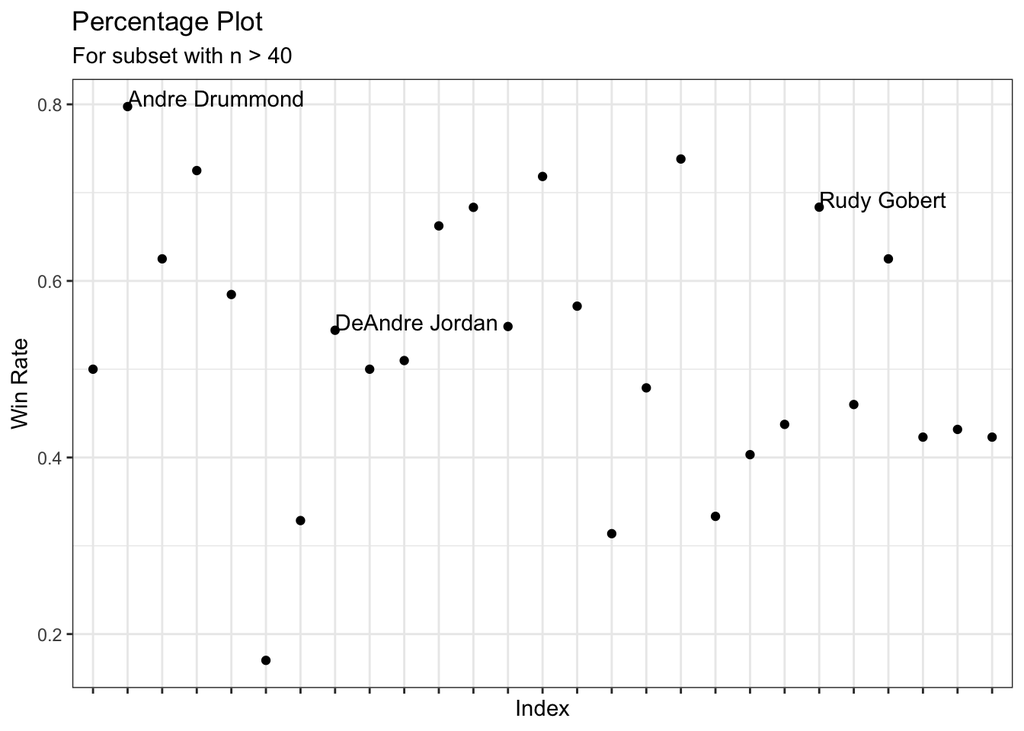

```r
ggplot(subtotal, aes(x= jumper, y= percentage)) +
  labs(subtitle="For subset with n > 40",
        y="Win Rate",
        x="Index",
        title="Percentage Plot") +
  theme_bw() +
  theme(axis.text.x = element_blank()) +
  geom_point() +
  geom_text(aes(label=ifelse(jumper == 'DeAndre Jordan' | jumper == 'Andre Drummond' | jumper == 'Rudy Gobert',as.character(jumper),'')),hjust=0,vjust=0)
```

## Methodology

-I used NBA play-by-play data scraped from ESPN.com using an original function

-I scraped the full 2018 season (1230 games) and the first ~25% of the 2019 season (308 games)

### **Input**

-Game ID

### **Output**

-Date, jumpers, teams, jump ball winner as well as which team shoots first and which team scores first

## Descriptive statistics

Is there something here?

## When you win do you shoot first?

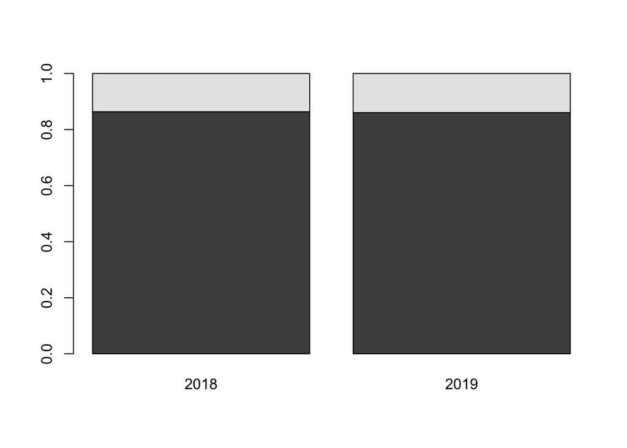

```r
barplot(as.matrix(a))
```

X ~ Geom(1-Turnover Rate), where winning team is the sum of the odds and losing team is the sum of the evens.

```r
sum(dgeom(0:10,0.87)[c(1,3,5,7,9)])
```

```
## [1] 0.8849558
```

## When you win do you score first?

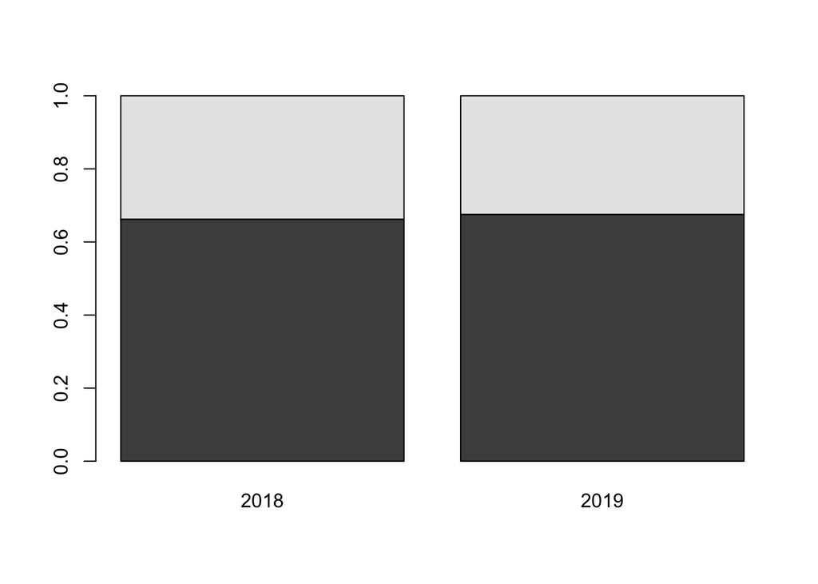

```r
barplot(as.matrix(b))
```

X ~ Geom(Scoring Rate), where winning team is the sum of the odds and losing team is the sum of the evens.

```r
sum(dgeom(0:10,0.5)[c(1,3,5,7,9)])
```

```
## [1] 0.6660156
```

## Distribution of win rate

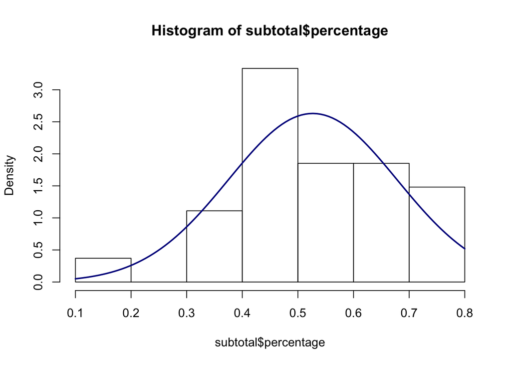

```r
hist(subtotal$percentage, freq = FALSE)
curve(dnorm(x, mean(subtotal$percentage), sd(subtotal$percentage)), add=TRUE, col="darkblue", lwd=2)
```

## Model

### **Elo Rating**

-Elo rating was originally developed as a chess rating system

-It is a method for calculating the relative skill of players in zero-sum games

-Adapted for competition in video games, football, basketball, baseball, table tennis and board games such as scrabble

-Ratings (numerical) change depending on the outcome of games played

-The difference in rating between two players serves as a predictor for the outcome of the match

## Implementation

K factor determines the magnitude by which the rating reacts to new game results

-In my analysis I couldn’t find a significant effect of k factor

-I borrowed k = 20 from a FiveThirtyEight analysis

```r
ELO(1500,1600,20)
```

```
##             chance.to.win home.jumper.wins road.jumper.wins
## home.jumper      0.359935             1513             1493
## away.jumper      0.640065             1587             1607
```

## ROC plot

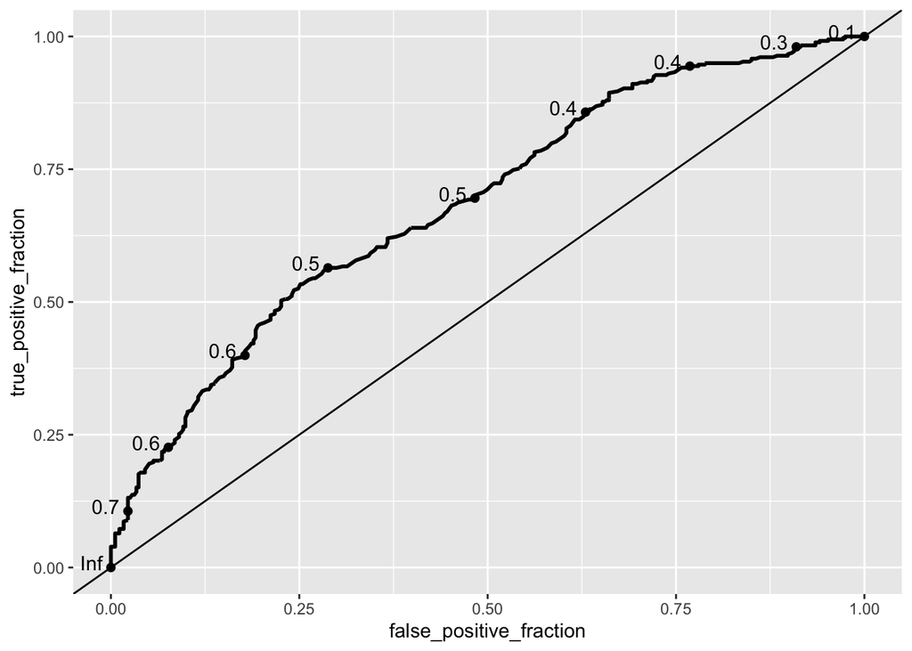

```r
k20 <- ggplot(relevant.2018.reg, aes(d = result, m = ELO.estimate.k20)) + geom_roc() + geom_abline(slope = 1, intercept = 0)
auc11 <- as.character(round(calc_auc(k20)$AUC, 2))
k20
```

```r
print(paste("Area under curve:", auc11))
```

```
## [1] "Area under curve: 0.68"
```

## Predicting Elo Rating based on physical characteristics

-NBA combine CSV containing data on the majority of players who entered the NBA between 2000 and 2018

-Data includes: height, weight, body fat percentage, wingspan, standing reach, vertical jump, lane agility, three quarters court sprint, and bench press

-Gathered and used by NBA as part of the draft process

## Multiple linear regression of ELO ratings on combine data

```r
fit <- lm(rating ~ HEIGHT_WO_SHOES + WEIGHT + WINGSPAN + STANDING_REACH + STANDING_VERTICAL_LEAP + BODY_FAT_PCT + LANE_AGILITY_TIME + THREE_QUARTER_SPRINT + BENCH_PRESS, data=physical.elo)
summary(fit)
```

```
##
## Call:
## lm(formula = rating ~ HEIGHT_WO_SHOES + WEIGHT + WINGSPAN + STANDING_REACH +
##     STANDING_VERTICAL_LEAP + BODY_FAT_PCT + LANE_AGILITY_TIME +
##     THREE_QUARTER_SPRINT + BENCH_PRESS, data = physical.elo)
##
## Residuals:
##      Min       1Q   Median       3Q      Max
## -115.768  -35.679   -9.803   38.725   96.473
##
## Coefficients:
##                        Estimate Std. Error t value Pr(>|t|)
## (Intercept)              0.8923   704.0977   0.001  0.99900
## HEIGHT_WO_SHOES         -6.8817     8.1008  -0.850  0.40281
## WEIGHT                   2.5967     0.8173   3.177  0.00361 **
## WINGSPAN                11.1141     5.9972   1.853  0.07442 .
## STANDING_REACH          -2.8225     7.9584  -0.355  0.72550
## STANDING_VERTICAL_LEAP   7.3799     4.7797   1.544  0.13382
## BODY_FAT_PCT            -9.9531     6.9687  -1.428  0.16428
## LANE_AGILITY_TIME       10.2113    22.4719   0.454  0.65304
## THREE_QUARTER_SPRINT   171.7138   118.1418   1.453  0.15721
## BENCH_PRESS             -3.6178     2.6305  -1.375  0.17993
## ---
## Signif. codes:  0 '***' 0.001 '**' 0.01 '*' 0.05 '.' 0.1 ' ' 1
##
## Residual standard error: 59.41 on 28 degrees of freedom
##   (27 observations deleted due to missingness)
## Multiple R-squared:  0.5008, Adjusted R-squared:  0.3404
## F-statistic: 3.121 on 9 and 28 DF,  p-value: 0.009971
```

## Multiple logistic regression of jumper(yes/no) on combine data

```r
model.j <- glm(rating ~ HEIGHT_WO_SHOES + WEIGHT + WINGSPAN + STANDING_REACH + STANDING_VERTICAL_LEAP + BODY_FAT_PCT + LANE_AGILITY_TIME + THREE_QUARTER_SPRINT + BENCH_PRESS, family = binomial(link = 'logit'), data=jumper.pred)
summary(model.j)
```

```
##
## Call:
## glm(formula = rating ~ HEIGHT_WO_SHOES + WEIGHT + WINGSPAN +
##     STANDING_REACH + STANDING_VERTICAL_LEAP + BODY_FAT_PCT +
##     LANE_AGILITY_TIME + THREE_QUARTER_SPRINT + BENCH_PRESS, family = binomial(link = "logit"),
##     data = jumper.pred)
##
## Deviance Residuals:
##      Min        1Q    Median        3Q       Max
## -1.55111  -0.25855  -0.10183  -0.03315   2.92527
##
## Coefficients:
##                          Estimate Std. Error z value Pr(>|z|)
## (Intercept)            -62.742611  12.225383  -5.132 2.86e-07 ***
## HEIGHT_WO_SHOES          0.247255   0.152610   1.620  0.10520
## WEIGHT                   0.029321   0.016202   1.810  0.07034 .
## WINGSPAN                 0.005166   0.133454   0.039  0.96912
## STANDING_REACH           0.394725   0.162892   2.423  0.01538 *
## STANDING_VERTICAL_LEAP   0.155549   0.088937   1.749  0.08029 .
## BODY_FAT_PCT            -0.322721   0.098546  -3.275  0.00106 **
## LANE_AGILITY_TIME       -1.300082   0.419694  -3.098  0.00195 **
## THREE_QUARTER_SPRINT     1.117696   1.864766   0.599  0.54892
## BENCH_PRESS             -0.006101   0.044921  -0.136  0.89196
## ---
## Signif. codes:  0 '***' 0.001 '**' 0.01 '*' 0.05 '.' 0.1 ' ' 1
##
## (Dispersion parameter for binomial family taken to be 1)
##
##     Null deviance: 304.96  on 791  degrees of freedom
## Residual deviance: 201.91  on 782  degrees of freedom
##   (483 observations deleted due to missingness)
## AIC: 221.91
##
## Number of Fisher Scoring iterations: 8
```

## Conclusion

-Elo model provides a significant predictor of jump ball success rate

-However, data suggets whether or not a player will join the subset of jumpers can be predicted by physical attributes

-There is a baseline physical ability to jump ball in the NBA, however, Elo rating is effective in quantifying the skill involved

-We can (somewhat) predict the toss up